# Extracting the city level data and Exporting to CSV:

select * from city_data where city='Cairo' and country='Egypt';

# Extracting the global data. Exporting to CSV:

select * from global_data

# Prepare the data to be visualized in the chart using python:

```python
import pandas as pd
import matplotlib.pyplot as plt
import numpy as np
```

```python
path1="C:\\Users\\El Zahraa\\Desktop\\code\\my folder\\Data Analysis_udacity\\results (1).csv"
path2="C:\\Users\\El Zahraa\\Desktop\\code\\my folder\\Data Analysis_udacity\\results (2).csv"
```

```python
df1 = pd.read_csv(path1)
df1.rename(columns={'avg_temp':'avg_temp_local'},inplace=True)
df2 = pd.read_csv(path2)
df2.rename(columns={'avg_temp':'avg_temp_global'},inplace=True)
```

# Calculating the moving average for local temperature:

```python
df1['MA_temp_local']=df1.iloc[:,3].rolling(window=10).mean()
df1.head()
```

|  | year | city | country | avg_temp_local | MA_temp_local |
| --- | --- | --- | --- | --- | --- |
| 0 | 1808 | Cairo | Egypt | 17.11 | NaN |
| 1 | 1809 | Cairo | Egypt | 19.87 | NaN |
| 2 | 1810 | Cairo | Egypt | 19.93 | NaN |
| 3 | 1811 | Cairo | Egypt | 20.00 | NaN |
| 4 | 1812 | Cairo | Egypt | 19.93 | NaN |

```python
df2.head()
```

|  | year | avg_temp_global |
| --- | --- | --- |
| 0 | 1750 | 8.72 |
| 1 | 1751 | 7.98 |
| 2 | 1752 | 5.78 |
| 3 | 1753 | 8.39 |
| 4 | 1754 | 8.47 |

# Calculating the moving average for global temperature:

```python
x=df2['year'].to_list()
x.index(1808)
df2_modified = df2[['avg_temp_global']][x.index(1808):x.index(2014)]
df2_modified.reset_index(drop=True,inplace=True)
df2_modified['MA_temp_global']=df2_modified.iloc[:,0].rolling(window=10).mean()
df2_modified.tail()
```

|  | avg_temp_global | MA_temp_global |
| --- | --- | --- |
| 201 | 9.51 | 9.493 |
| 202 | 9.70 | 9.543 |
| 203 | 9.52 | 9.554 |
| 204 | 9.51 | 9.548 |
| 205 | 9.61 | 9.556 |

```python
df = pd.concat([df1,df2_modified],axis=1)
```

```python
df.head(20)
```

|  | year | city | country | avg_temp_local | MA_temp_local | avg_temp_global | MA_temp_global |
| --- | --- | --- | --- | --- | --- | --- | --- |
| 0 | 1808 | Cairo | Egypt | 17.11 | NaN | 7.63 | NaN |
| 1 | 1809 | Cairo | Egypt | 19.87 | NaN | 7.08 | NaN |
| 2 | 1810 | Cairo | Egypt | 19.93 | NaN | 6.92 | NaN |
| 3 | 1811 | Cairo | Egypt | 20.00 | NaN | 6.86 | NaN |
| 4 | 1812 | Cairo | Egypt | 19.93 | NaN | 7.05 | NaN |
| 5 | 1813 | Cairo | Egypt | 20.51 | NaN | 7.74 | NaN |
| 6 | 1814 | Cairo | Egypt | 20.43 | NaN | 7.59 | NaN |
| 7 | 1815 | Cairo | Egypt | 20.30 | NaN | 7.24 | NaN |
| 8 | 1816 | Cairo | Egypt | 20.51 | NaN | 6.94 | NaN |
| 9 | 1817 | Cairo | Egypt | 21.88 | 20.047 | 6.98 | 7.203 |
| 10 | 1818 | Cairo | Egypt | 11.60 | 19.496 | 7.83 | 7.223 |
| 11 | 1819 | Cairo | Egypt | 20.31 | 19.540 | 7.37 | 7.252 |
| 12 | 1820 | Cairo | Egypt | 20.58 | 19.605 | 7.62 | 7.322 |
| 13 | 1821 | Cairo | Egypt | 20.63 | 19.668 | 8.09 | 7.445 |
| 14 | 1822 | Cairo | Egypt | 20.72 | 19.747 | 8.19 | 7.559 |
| 15 | 1823 | Cairo | Egypt | 20.71 | 19.767 | 7.72 | 7.557 |
| 16 | 1824 | Cairo | Egypt | 21.44 | 19.868 | 8.55 | 7.653 |
| 17 | 1825 | Cairo | Egypt | 21.00 | 19.938 | 8.39 | 7.768 |
| 18 | 1826 | Cairo | Egypt | 20.94 | 19.981 | 8.36 | 7.910 |
| 19 | 1827 | Cairo | Egypt | 21.63 | 19.956 | 8.81 | 8.093 |

```python
df.tail(10)
```

|  | year | city | country | avg_temp_local | MA_temp_local | avg_temp_global | MA_temp_global |
| --- | --- | --- | --- | --- | --- | --- | --- |
| 196 | 2004 | Cairo | Egypt | 22.08 | 22.001 | 9.32 | 9.343 |
| 197 | 2005 | Cairo | Egypt | 22.01 | 22.046 | 9.70 | 9.378 |
| 198 | 2006 | Cairo | Egypt | 22.05 | 22.063 | 9.53 | 9.427 |
| 199 | 2007 | Cairo | Egypt | 22.36 | 22.154 | 9.73 | 9.480 |
| 200 | 2008 | Cairo | Egypt | 22.64 | 22.182 | 9.43 | 9.471 |
| 201 | 2009 | Cairo | Egypt | 22.63 | 22.217 | 9.51 | 9.493 |
| 202 | 2010 | Cairo | Egypt | 23.72 | 22.440 | 9.70 | 9.543 |
| 203 | 2011 | Cairo | Egypt | 21.99 | 22.406 | 9.52 | 9.554 |
| 204 | 2012 | Cairo | Egypt | 22.48 | 22.413 | 9.51 | 9.548 |
| 205 | 2013 | Cairo | Egypt | 22.91 | 22.487 | 9.61 | 9.556 |

# Data Visualization:

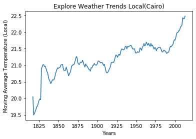

```python
plt.plot(df['year'],df['MA_temp_local'])
plt.xlabel('Years')
plt.ylabel('Moving Average Temperature (Local)')
plt.title("Explore Weather Trends Local(Cairo)")
```

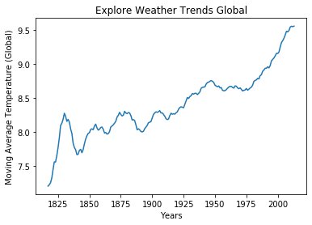

```python
plt.plot(df['year'],df['MA_temp_global'])
plt.xlabel('Years')
plt.ylabel('Moving Average Temperature (Global)')
plt.title("Explore Weather Trends Global")
```

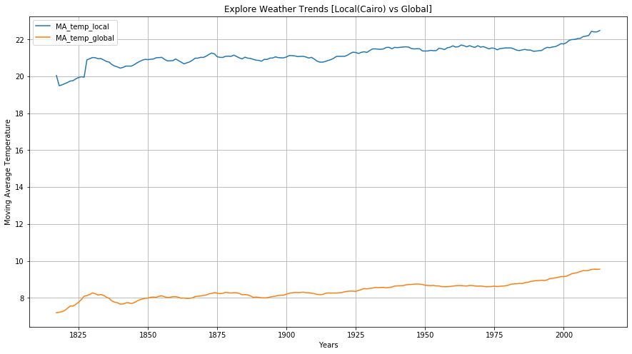

```python
plt.figure(figsize=(15,8))
plt.plot(df['year'],df['MA_temp_local'],label='MA_temp_local')
plt.plot(df['year'],df['MA_temp_global'],label='MA_temp_global')
plt.xlabel('Years')
plt.ylabel('Moving Average Temperature')
plt.title("Explore Weather Trends [Local(Cairo) vs Global]")
plt.legend()
plt.grid(True)
```

# Observations:

As we see from the chart that Egypt(Cairo) average temperature is hotter than global average temperature.

Differance between local and average temperature is almost constant.

For global average, the change in temperature for the 19th century is almost constant, but for the 20th century it is observed that temperature is getting higher.

As we see in the previous point that the world is getting hotter which it is called "Global Warming" in the 21th cenyury.

As well, we see in local average that temperature is getting hotter starting from 2000 (21th century) and that is a correct indicator about the change in temperature for the average of the global temperature.

As we will see in the next section that calculating correlation between data will confirm the previous two points

# Save modified data to new csv file:

```python
df.to_csv('total_temp.csv')
```

# Correlation between data:

```python
df[['year','MA_temp_local','MA_temp_global']].corr()
```

|  | year | MA_temp_local | MA_temp_global |
| --- | --- | --- | --- |
| year | 1.000000 | 0.866663 | 0.924778 |
| MA_temp_local | 0.866663 | 1.000000 | 0.932544 |
| MA_temp_global | 0.924778 | 0.932544 | 1.000000 |

```python
from scipy import stats
df.dropna(subset=['MA_temp_local'],axis=0,inplace=True)
df.dropna(subset=['MA_temp_global'],axis=0,inplace=True)
```

```python
pearson_coef, p_value = stats.pearsonr(df['MA_temp_local'], df['MA_temp_global'])
print(f'The Pearson Correlation Coefficient is {pearson_coef}')
print(f'with a P-value of P = {p_value}')
```

```
The Pearson Correlation Coefficient is 0.9325437121930521
with a P-value of P = 3.263351793117509e-88
```

```python
pearson_coef, p_value = stats.pearsonr(df['MA_temp_local'], df['year'])
print(f'The Pearson Correlation Coefficient is {pearson_coef}')
print(f'with a P-value of P = {p_value}')
```

```
The Pearson Correlation Coefficient is 0.86666301713461
with a P-value of P = 8.49965931579098e-61
```

```python
pearson_coef, p_value = stats.pearsonr(df['MA_temp_global'], df['year'])
print(f'The Pearson Correlation Coefficient is {pearson_coef}')
print(f'with a P-value of P = {p_value}')
```

```
The Pearson Correlation Coefficient is 0.9247781432590557
with a P-value of P = 9.133072732434628e-84
```

# Estimation the average temperature in your city based on the average global temperature:

```python
from sklearn.linear_model import LinearRegression
```

```python
df.dtypes
```

```
year                 int64
city                object
country             object
avg_temp_local     float64
MA_temp_local      float64
avg_temp_global    float64
MA_temp_global     float64
dtype: object
```

```python
lm=LinearRegression()
x=df[['avg_temp_global']]
y=df['avg_temp_local']
lm.fit(x,y)
yhat=lm.predict(x)
```

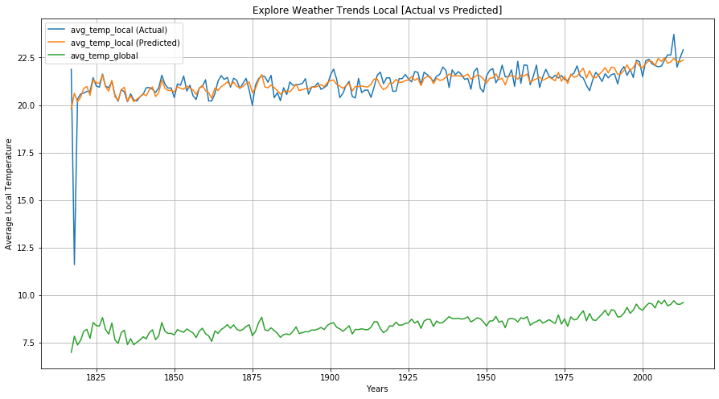

```python
plt.figure(figsize=(15,8))
plt.plot(df['year'],y,label='avg_temp_local (Actual)')
plt.plot(df['year'],yhat,label='avg_temp_local (Predicted)')
plt.plot(df['year'],x,label='avg_temp_global')
plt.xlabel('Years')
plt.ylabel('Average Local Temperature')
plt.title("Explore Weather Trends Local [Actual vs Predicted]")
plt.legend()
plt.grid(True)
```

```python
jupyter nbconvert thenotebook.ipynb --to latex
```

[output not shown]